# January 23

## Packages

```r
library(MASS)
library(tidyverse)
library(nnet) # for multinom later
```

## Ordered responses

See slides 120 and 121.

### The data

The miners data:

```r
my_url="http://www.utsc.utoronto.ca/~butler/d29/miners-tab.txt"
freqs=read_table(my_url)
freqs
```

| Exposure | None | Moderate | Severe |
| --- | --- | --- | --- |
| 5.8 | 98 | 0 | 0 |
| 15.0 | 51 | 2 | 1 |
| 21.5 | 34 | 6 | 3 |
| 27.5 | 35 | 5 | 8 |
| 33.5 | 32 | 10 | 9 |
| 39.5 | 23 | 7 | 8 |
| 46.0 | 12 | 6 | 10 |
| 51.5 | 4 | 2 | 5 |

### Long format and a plot

Making long format and proportions

```r
freqs %>% gather(Severity, Freq, -Exposure) %>%
group_by(Exposure) %>%
mutate(proportion=Freq/sum(Freq)) -> miners
miners
```

| Exposure | Severity | Freq | proportion |
| --- | --- | --- | --- |
| 5.8 | None | 98 | 1.00000000 |
| 15.0 | None | 51 | 0.94444444 |
| 21.5 | None | 34 | 0.79069767 |
| 27.5 | None | 35 | 0.72916667 |
| 33.5 | None | 32 | 0.62745098 |
| 39.5 | None | 23 | 0.60526316 |
| 46.0 | None | 12 | 0.42857143 |
| 51.5 | None | 4 | 0.36363636 |
| 5.8 | Moderate | 0 | 0.00000000 |
| 15.0 | Moderate | 2 | 0.03703704 |

[output cut: 14 more lines]

plot proportions against exposure

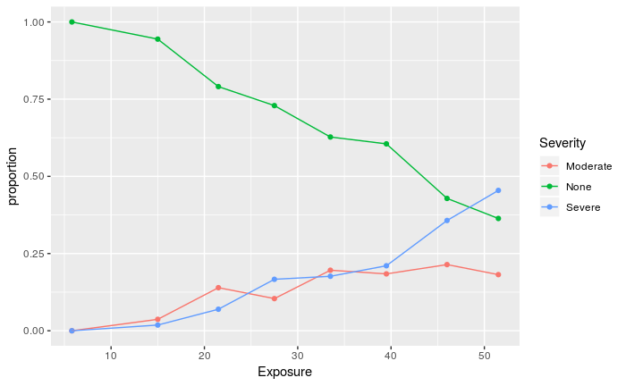

```r
ggplot(miners,aes(x=Exposure,y=proportion,
colour=Severity))+geom_point()+geom_line()
```

### Re-ordering the categories

but, categories in *wrong order*!

in *data frame*, severity categories in *correct* order:

```r
miners
```

| Exposure | Severity | Freq | proportion |
| --- | --- | --- | --- |
| 5.8 | None | 98 | 1.00000000 |
| 15.0 | None | 51 | 0.94444444 |
| 21.5 | None | 34 | 0.79069767 |
| 27.5 | None | 35 | 0.72916667 |
| 33.5 | None | 32 | 0.62745098 |
| 39.5 | None | 23 | 0.60526316 |
| 46.0 | None | 12 | 0.42857143 |
| 51.5 | None | 4 | 0.36363636 |
| 5.8 | Moderate | 0 | 0.00000000 |
| 15.0 | Moderate | 2 | 0.03703704 |

[output cut: 14 more lines]

so create a factor with levels in *that* order. Use `fct_inorder` from `forcats` (part of `tidyverse`):

```r
miners %>%
mutate(sev_ord=fct_inorder(Severity)) -> miners
```

```r
miners
```

| Exposure | Severity | Freq | proportion | sev_ord |
| --- | --- | --- | --- | --- |
| 5.8 | None | 98 | 1.00000000 | None |
| 15.0 | None | 51 | 0.94444444 | None |
| 21.5 | None | 34 | 0.79069767 | None |
| 27.5 | None | 35 | 0.72916667 | None |
| 33.5 | None | 32 | 0.62745098 | None |
| 39.5 | None | 23 | 0.60526316 | None |
| 46.0 | None | 12 | 0.42857143 | None |
| 51.5 | None | 4 | 0.36363636 | None |
| 5.8 | Moderate | 0 | 0.00000000 | Moderate |
| 15.0 | Moderate | 2 | 0.03703704 | Moderate |

[output cut: 14 more lines]

Did that work?

```r
levels(miners$sev_ord)
```

```
[1] "None"     "Moderate" "Severe"
```

### A more sensible plot

better plot:

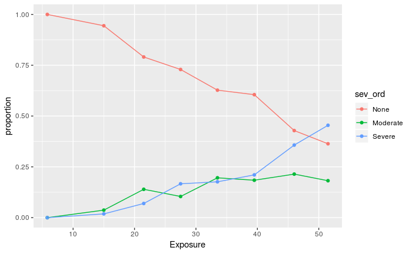

```r
ggplot(miners,aes(x=Exposure,y=proportion,
colour=sev_ord))+geom_point()+geom_line()
```

so it looks as if severity of disease does depend on exposure.

### Fitting a model

To model, use “proportional odds logistic regression”, thus. `weights` is how to say that each row represents several people:

```r
sev.1=polr(sev_ord~Exposure, weights=Freq, data=miners)
```

the output doesn’t say much:

```r
sev.1
```

```
Call:
polr(formula = sev_ord ~ Exposure, data = miners, weights = Freq)

Coefficients:
  Exposure
0.09590405

Intercepts:
  None|Moderate Moderate|Severe
       3.955843        4.869048

Residual Deviance: 416.9188
AIC: 422.9188
```

we’ll investigate using predictions later.

### Testing effect of exposure

Does exposure have an effect? The obvious way:

```r
drop1(sev.1, test="Chisq")
```

```
Single term deletions

Model:
sev_ord ~ Exposure
         Df    AIC    LRT  Pr(>Chi)
<none>      422.92
Exposure  1 509.16 88.243 < 2.2e-16 ***
---
Signif. codes:  0 ‘***’ 0.001 ‘**’ 0.01 ‘*’ 0.05 ‘.’ 0.1 ‘ ’ 1
```

This also works (but is a bit longer): - fit a model without exposure - use `anova` to compare models with and without:

```r
sev.2=update(sev.1, .~.-Exposure)
anova(sev.2,sev.1)
```

```
Likelihood ratio tests of ordinal regression models

Response: sev_ord
     Model Resid. df Resid. Dev   Test    Df LR stat. Pr(Chi)
1        1       369   505.1621
2 Exposure       368   416.9188 1 vs 2     1 88.24324       0
```

Same test and save result: exposure matters.

### Predictions and another plot

To understand what the model is saying, *make predictions* for various exposures. Which exposures? Look back at original dataframe:

```r
freqs
```

| Exposure | None | Moderate | Severe |
| --- | --- | --- | --- |
| 5.8 | 98 | 0 | 0 |
| 15.0 | 51 | 2 | 1 |
| 21.5 | 34 | 6 | 3 |
| 27.5 | 35 | 5 | 8 |
| 33.5 | 32 | 10 | 9 |
| 39.5 | 23 | 7 | 8 |
| 46.0 | 12 | 6 | 10 |
| 51.5 | 4 | 2 | 5 |

The ones in column called `Exposure` here would be good.

```r
#pr=predict(sev.1, freqs, type="bananas")
```

probs, then:

```r
pr=predict(sev.1, freqs, type="probs")
(miners.pred=cbind(freqs, pr))
```

|  | Exposure | None | Moderate | Severe | None | Moderate | Severe |
| --- | --- | --- | --- | --- | --- | --- | --- |
| 1 | 5.8 | 98 | 0 | 0 | 0.9676920 | 0.01908912 | 0.01321885 |
| 2 | 15.0 | 51 | 2 | 1 | 0.9253445 | 0.04329931 | 0.03135614 |
| 3 | 21.5 | 34 | 6 | 3 | 0.8692003 | 0.07385858 | 0.05694115 |
| 4 | 27.5 | 35 | 5 | 8 | 0.7889290 | 0.11413004 | 0.09694093 |
| 5 | 33.5 | 32 | 10 | 9 | 0.6776641 | 0.16207145 | 0.16026444 |
| 6 | 39.5 | 23 | 7 | 8 | 0.5418105 | 0.20484198 | 0.25334756 |
| 7 | 46.0 | 12 | 6 | 10 | 0.3879962 | 0.22441555 | 0.38758828 |
| 8 | 51.5 | 4 | 2 | 5 | 0.2722543 | 0.21025011 | 0.51749563 |

we got repeated column names. Let’s rename the ones that came from `freqs`:

```r
pr=predict(sev.1, freqs, type="probs")
(miners.pred=cbind(f=freqs, pr))
```

|  | f.Exposure | f.None | f.Moderate | f.Severe | None | Moderate | Severe |
| --- | --- | --- | --- | --- | --- | --- | --- |
| 1 | 5.8 | 98 | 0 | 0 | 0.9676920 | 0.01908912 | 0.01321885 |
| 2 | 15.0 | 51 | 2 | 1 | 0.9253445 | 0.04329931 | 0.03135614 |
| 3 | 21.5 | 34 | 6 | 3 | 0.8692003 | 0.07385858 | 0.05694115 |
| 4 | 27.5 | 35 | 5 | 8 | 0.7889290 | 0.11413004 | 0.09694093 |
| 5 | 33.5 | 32 | 10 | 9 | 0.6776641 | 0.16207145 | 0.16026444 |
| 6 | 39.5 | 23 | 7 | 8 | 0.5418105 | 0.20484198 | 0.25334756 |
| 7 | 46.0 | 12 | 6 | 10 | 0.3879962 | 0.22441555 | 0.38758828 |
| 8 | 51.5 | 4 | 2 | 5 | 0.2722543 | 0.21025011 | 0.51749563 |

Want to plot these, so need all the predicted probabilities in one column:

```r
miners.pred %>% select(Exposure=f.Exposure, None:Severe) %>%
  gather(Severity, probability, -Exposure) %>%
  mutate(sev_ord=fct_inorder(Severity)) -> preds
preds
```

| Exposure | Severity | probability | sev_ord |
| --- | --- | --- | --- |
| 5.8 | None | 0.96769203 | None |
| 15.0 | None | 0.92534455 | None |
| 21.5 | None | 0.86920028 | None |
| 27.5 | None | 0.78892903 | None |
| 33.5 | None | 0.67766411 | None |
| 39.5 | None | 0.54181046 | None |
| 46.0 | None | 0.38799618 | None |
| 51.5 | None | 0.27225426 | None |
| 5.8 | Moderate | 0.01908912 | Moderate |
| 15.0 | Moderate | 0.04329931 | Moderate |

[output cut: 14 more lines]

When we made our first plot, we got this:

```r
miners
```

| Exposure | Severity | Freq | proportion | sev_ord |
| --- | --- | --- | --- | --- |
| 5.8 | None | 98 | 1.00000000 | None |
| 15.0 | None | 51 | 0.94444444 | None |
| 21.5 | None | 34 | 0.79069767 | None |
| 27.5 | None | 35 | 0.72916667 | None |
| 33.5 | None | 32 | 0.62745098 | None |
| 39.5 | None | 23 | 0.60526316 | None |
| 46.0 | None | 12 | 0.42857143 | None |
| 51.5 | None | 4 | 0.36363636 | None |
| 5.8 | Moderate | 0 | 0.00000000 | Moderate |
| 15.0 | Moderate | 2 | 0.03703704 | Moderate |

[output cut: 14 more lines]

Let’s match them on what they match on, to make one data frame with everything needed for plot of data and predictions:

```r
(preds %>% left_join(miners) -> plot_stuff)
```

| Exposure | Severity | probability | sev_ord | Freq | proportion |
| --- | --- | --- | --- | --- | --- |
| 5.8 | None | 0.96769203 | None | 98 | 1.00000000 |
| 15.0 | None | 0.92534455 | None | 51 | 0.94444444 |
| 21.5 | None | 0.86920028 | None | 34 | 0.79069767 |
| 27.5 | None | 0.78892903 | None | 35 | 0.72916667 |
| 33.5 | None | 0.67766411 | None | 32 | 0.62745098 |
| 39.5 | None | 0.54181046 | None | 23 | 0.60526316 |
| 46.0 | None | 0.38799618 | None | 12 | 0.42857143 |
| 51.5 | None | 0.27225426 | None | 4 | 0.36363636 |
| 5.8 | Moderate | 0.01908912 | Moderate | 0 | 0.00000000 |
| 15.0 | Moderate | 0.04329931 | Moderate | 2 | 0.03703704 |

[output cut: 14 more lines]

All right, plot: - proportion vs exposure as points - probability vs exposure joined by lines - severity categories distinguished by colour

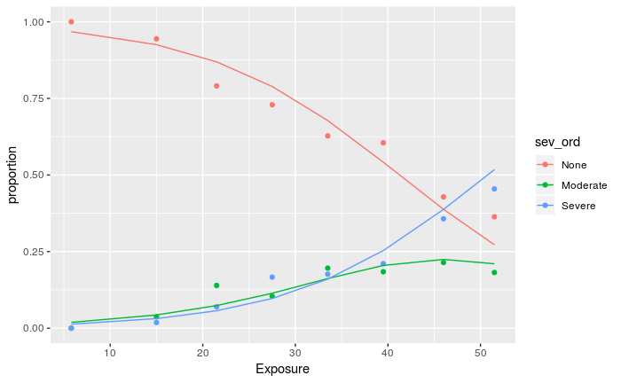

```r
ggplot(plot_stuff, aes(x=Exposure, y=proportion, colour=sev_ord)) +
  geom_point()+
  geom_line(aes(y=probability))
```

The curves match the points pretty well, suggesting that the model is doing a good job of fitting the data.

Technical note: the y-variable for the points and the lines is different, so the `geom_line` has an extra `aes` in it with the new y. (The x and the colour is the same, so don’t say those again.)

## Unordered responses

When the response categories are not ordered (they are just labels), we have to fit using “generalized logits”, using `multinom` from package `nnet`.

Example: 735 people, record age, sex and brand of some product preferred:

```r
my_url="http://www.utsc.utoronto.ca/~butler/d29/mlogit.csv"
brandpref=read_csv(my_url)
brandpref
```

[output not shown]

Data are one row per individual (even though a lot of individuals might have same age/sex combo).

Brand and sex really ought to be categorical:

```r
brandpref %>%
  mutate(sex=ifelse(sex==1, "female", "male")) %>%
  mutate(brand=factor(brand)) -> brandpref
brandpref
```

[output not shown]

Calculating the mean brand should be impossible now:

```r
brandpref %>% summarize(m=mean(brand))
```

[output not shown]

How many males and females do we have?

```r
brandpref %>% count(sex)
```

[output not shown]

how many preferences for each brand?

```r
brandpref %>% count(brand)
```

[output not shown]

Fit a model:

```r
brand.1=multinom(brand~age+sex, data=brandpref)
```

```r
summary(brand.1)
```

[output not shown]

Lots of coefficients but not much insight.

What can we drop?

```r
drop1(brand.1)
```

[output not shown]

Oh. All right then. Fit models without `sex` and `age` and compare them for fit with `anova`:

```r
brand.2=update(brand.1,.~.-sex)
brand.3=update(brand.1,.~.-age)
```

then

```r
anova(brand.2,brand.1)
```

[output not shown]

Taking `sex` out is a mistake. And:

```r
anova(brand.3,brand.1)
```

[output not shown]

taking `age` out is a definite mistake.

This, mysteriously, works, and gives effectively the same conclusion:

```r
step(brand.1, trace=2)
```

[output not shown]

I can’t make it do a test.

### Predictions

Make combination of various ages and sexes:

```r
ages=c(24,28,32,35,38)
sexes=c("female", "male")
new=crossing(age=ages,sex=sexes)
new
```

[output not shown]

Predict:

```r
p=predict(brand.1,new,type="probs")
probs=cbind(new,p)
probs
```

[output not shown]

What is effect of age? Concentrate on females:

```r
probs %>% filter(sex=="female")
```

[output not shown]

Young people prefer brand 1. Older people prefer brand 3. People with age in the middle prefer brand 2.

The pattern is similar for males:

```r
probs %>% filter(sex=="male")
```

[output not shown]

What is difference between males and females? Pick an age, say 32:

```r
probs %>% filter(age==32)
```

[output not shown]

At this age, females like brand 2 more and brand 1 less. What about younger people?

```r
probs %>% filter(age==24)
```

[output not shown]

At this age, almost everyone likes brand 1, but still same pattern: females like brand 2 more and brand 1 less.

### Making a plot

```r
probs
```

[output not shown]

Above data frame not tidy, so do that first:

```r
(probs %>% gather(brand, probability, `1`:`3`) -> probs.long)
```

[output not shown]

We have *four* variables: age and probability (quantitative), sex and brand preferred (categorical).

Idea: plot probability against age, distinguishing brand by colour and gender by symbol shape and line type.

Now breathe, and make the plot:

```r
ggplot(probs.long, aes(x=age, y=probability, colour=brand, shape=sex, linetype=sex))+
  geom_point()+geom_line()
```

[output not shown]

### Alternative data format

There were this many people in our data set:

```r
nrow(brandpref)
```

[output not shown]

It seems likely that there is more than one person of each age-sex-brand combination. Can we summarize the data with frequencies for each combination?

```r
brandpref
(brandpref %>% count(age, sex, brand) -> b)
```

[output not shown]

This summarizes same data in 65 rows, but now each row is (possibly) more than one person.

How is this incorporated into modelling? Add a `weights` to `multinom` with name of column containing frequencies:

```r
b.1=multinom(brand~age+sex, data=b, weights=n)
```

Test for sex difference:

```r
b.2=update(b.1,.~.-sex)
anova(b.2,b.1)
```

[output not shown]

Exactly as before.

### Making a plot with data and predictions

```r
b
```

[output not shown]

On the plot, put proportions of people of each age-sex combo that preferred each brand, which we have to work out first:

```r
b %>% group_by(age, sex) %>%
  mutate(total=sum(n)) %>%
  mutate(proportion=n/total) -> bb
bb
```

[output not shown]

Take previous plot and:

- remove geom_point for predictions
- add proportions above as points

gives

```r
ggplot(probs.long, aes(x=age, y=probability, colour=brand, shape=sex, linetype=sex))+
  geom_line()+
  geom_point(data=bb, aes(y=proportion))
```

[output not shown]

One more refinement: those circles represent different numbers of people, in `total`. Use that to control *size* of plotted points:

```r
ggplot(probs.long, aes(x=age, y=probability, colour=brand, shape=sex, linetype=sex))+
  geom_line()+
  geom_point(data=bb, aes(y=proportion, size=total))
```

[output not shown]

The curves follow the points (especially the big points) pretty well.

### Interaction

So far, we assumed that effect of age is same for males and females. Is there evidence that it’s different?

Add *interaction term*:

```r
b.3=update(b.1, .~.+age:sex)
anova(b.1, b.3)
```

[output not shown]

or if you like

```r
step(b.3, trace=2)
```

[output not shown]

the interaction goes but age and sex stay.

So there’s no evidence that the effect of age is different for males and females.